# Skilaverkefni 4

Brynjólfur Gauti Jónsson

Þórarinn Jónmundsson

```r
packages <- c("ggthemes", "knitr", "kableExtra", "scales", "ggforce", "ggsci",
              "broom", "lubridate", "fBasics", "tidyquant", "tidyverse", "sweep")
sapply(packages, require, character.only = TRUE, quietly = TRUE)
options(knitr.table.format = "html", knitr.kable.NA = "")
theme_set(theme_tufte(base_size = 14) +
                theme(panel.border = element_rect(fill = NA),
                      panel.grid.major = element_line(color = "gray78"),
                      legend.background = element_rect(),
                      legend.position = "top",
                      strip.background = element_rect(fill = "grey88")))
```

```r
url <- "https://www.sedlabanki.is/xmltimeseries/Default.aspx?DagsFra=1999-01-05&DagsTil=2018-09-28&TimeSeriesID=4064&Type=csv"
data <- read_delim(url, delim = ";", col_names = as.character(seq(1:8))) %>%
      select(7:8) %>%
      set_names(c("Date", "Series")) %>%
      mutate(Date = mdy_hms(Date))
```

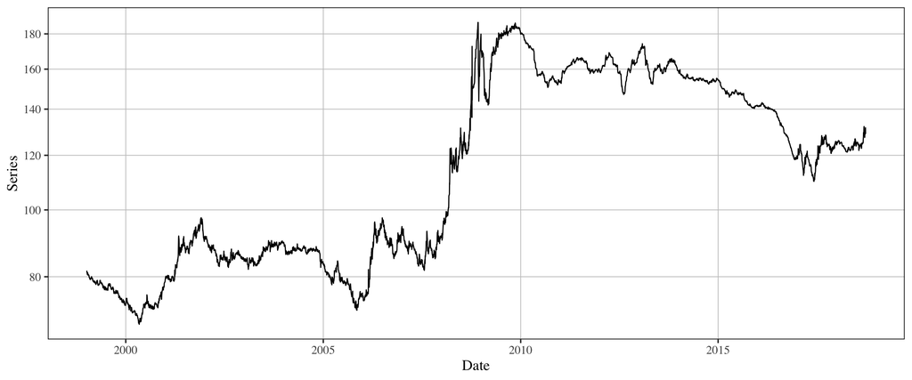

```r
data %>%
      ggplot(aes(Date, Series)) +
      geom_line() +
      scale_y_log10(breaks = pretty_breaks(8))
```

## 1. hluti: Ávöxtun

- Reiknið daglegu lograávöxtun tímaraðarinnar. Út frá því, reiknið einfalda ávöxtun raðarinnar.

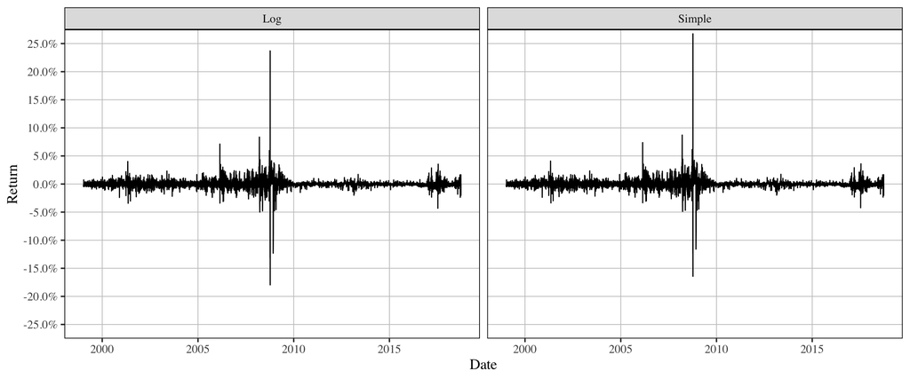

```r
# Hér kemur R-kóðablokk.
# Nauðsynlegt er að hafa mismunandi heiti á öllum blokkum í .Rmd skránni.
# T.d. heitir þessi blokk 'return'.
# basicStats(...)
data <- data %>%
      mutate(Log = c(NA, diff(log(Series))),
             Simple = exp(Log) - 1)
data %>%
      gather(Type, Return, Log, Simple) %>%
      ggplot(aes(Date, Return)) +
      geom_line() +
      facet_grid("Type") +
      scale_y_continuous(breaks = pretty_breaks(8), labels = percent) +
      coord_cartesian(ylim = c(-0.25, 0.25))
```

- Reiknið út frá formúlum fyrir þýði: Væntigildi, flökt, skeifni, og umfram reisni lograávöxtunarinnar. Staðfestið reikninga með R-fallinu ‘basicStats’.

```r
data %>%
      na.omit %>%
      summarize(N = n() - 1,
                Væntigildi = mean(Log),
                Dreifni = var(Log),
                Staðalfrávik = sqrt(Dreifni),
                Skeifni = sum((Log - Væntigildi)^3) / (N * Staðalfrávik^3),
                `Umram reisni` = sum((Log - Væntigildi)^4) / (N * Staðalfrávik^4) - 3) %>%
      gather(Stat, Value) %>%
      kable(format = "html") %>%
      kable_styling(bootstrap_options = c("striped", "hover"))
```

| Stat | Value |
| --- | --- |
| N | 4919.0000000 |
| Væntigildi | 0.0000928 |
| Dreifni | 0.0000701 |
| Staðalfrávik | 0.0083728 |
| Skeifni | 1.5059743 |
| Umram reisni | 202.8778739 |

## 2. hluti: Dreifing

- Eru væntigildi, skeifni, og umfram reisn lograávöxtunarinnar marktækt frábrugðnar núlli? Setjið fram og reiknið þrjár núlltilgátur með $5\%$ marktækni. Reiknið í kjölfarið $95\%$ öryggisbil væntigildis, skeifni, og umfram reisnar.

```r
data %>%
      na.omit %>%
      summarize(N = n(),
                Væntigildi = mean(Log),
                Dreifni = var(Log),
                Staðalfrávik = sqrt(Dreifni),
                Skeifni = sum((Log - Væntigildi)^3) / ((N - 1) * Staðalfrávik^3),
                `Umram reisni` = sum((Log - Væntigildi)^4) / ((N - 1) * Staðalfrávik^4) - 3) %>%
      summarize(z_Væntigildi = Væntigildi / (Staðalfrávik / sqrt(N)),
                z_Samhverfa = Skeifni / sqrt(6 / N),
                z_Halar = (`Umram reisni` - 3) / sqrt(24 / N),
                p_Væntigildi = qt(z_Væntigildi, df = 4919),
                p_Samhvefa = 2 * (1  - pnorm(z_Samhverfa)),
                p_Halar = 2 * (1 - pnorm(z_Halar))) %>%
      (function(x) {
            Z <- t(x)[1:3, , drop = T]
            P <- t(x)[4:6, , drop = T]
            Breyta <- names(x)[1:3]
            cbind(Breyta, Z, P)
      }) %>%
      as_tibble %>%
      mutate(Breyta = str_replace(Breyta, "z_", "")) %>%
      mutate_at(c("Z", "P"), as.numeric) %>%
      kable(format = "html") %>%
      kable_styling(bootstrap_options = c("striped", "hover"))
```

| Breyta | Z | P |
| --- | --- | --- |
| Væntigildi | 0.7776649 | 0.7643922 |
| Samhverfa | 43.1245399 | 0.0000000 |
| Halar | 2861.8156331 | 0.0000000 |

- Teiknið dreifingu ávöxtunarinnar (notið R-fallið ‘density’) og berið saman við normaldreifingu með sama væntigildi og flökt. Hvað getiði sagt um dreifingu ávöxtunarinnar útfrá grafinu og fyrri lið?

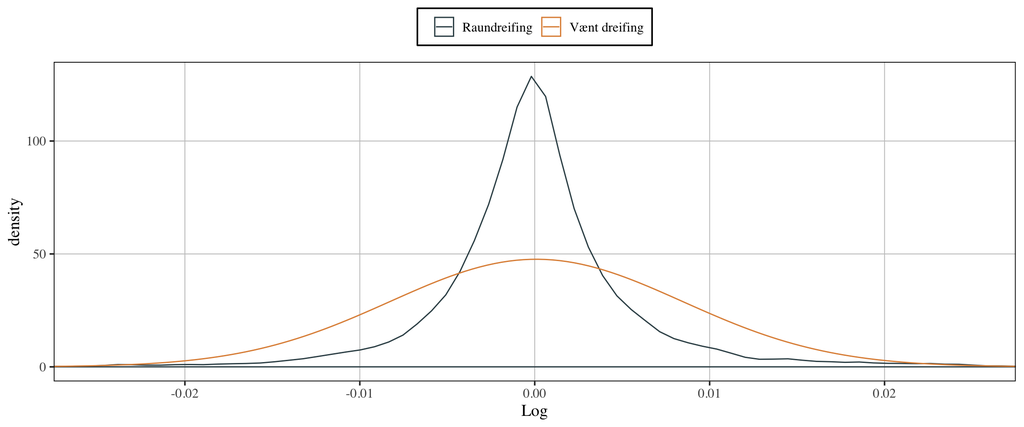

```r
plot_dat <- summarize(data, mean = mean(Log, na.rm = T), sd = sd(Log, na.rm = T))
ggplot(data, aes(Log)) +
      geom_density(aes(col = "Raundreifing")) +
      stat_function(fun = dnorm, n = 1000, args = list(mean = plot_dat$mean,
                                                       sd = plot_dat$sd),
                    aes(col = "Vænt dreifing")) +
      scale_color_jama(guide = guide_legend(title = "")) +
      coord_cartesian(xlim = c(-0.025, 0.025))
```

## 3. hluti: Sjálffylgnifall

- Reiknið útfrá formúlum sjálffylgnistuðla lograávöxtunarinnar fyrir eins og tveggja daga seinkanir (e. lags). Staðfestið reikninga með R-fallinu ‘acf’. Notið hornsviga og lengd ávöxtunarraðarinnar til að ná í bút úr ávöxtunarröðinni.

```r
data %>%
      select(Date, Log) %>%
      tq_mutate(select = Log, mutate_fun = lag.xts, k = 1:2,
                col_rename = paste0("Lag_", 1:2)) %>%
      gather(Lag, value, contains("Lag")) %>%
      group_by(Lag) %>%
      summarize(AC_cor = cor(Log, value, use = "pairwise.complete.obs"),
                AC_cov = cov(Log, value, use = "pairwise.complete.obs") /
                      (sqrt(var(Log, use = "pairwise.complete.obs") *
                                  var(value, use = "pairwise.complete.obs"))),
                mean = mean(Log, na.rm = T),
                AC_fmla = sum((Log - mean) * (value - mean), na.rm = T) /
                      sum((Log - mean)^2, na.rm = T)) %>%
      select(-mean) %>%
      kable(format = "html") %>%
      kable_styling(bootstrap_options = c("striped", "hover"))
```

| Lag | AC_cor | AC_cov | AC_fmla |
| --- | --- | --- | --- |
| Lag_1 | -0.1560283 | -0.1560421 | -0.1560262 |
| Lag_2 | 0.1139076 | 0.1139269 | 0.1138348 |

- Notið ACF-fallið til að fá fleiri sjálffylgnistuðla. Hvaða stuðlar eru marktækt frábrugðnir núlli? Setjið fram og reiknið núlltilgátur með $5\%$ marktækni. Bláu brotalínurnar í grafi ACF-fallsins koma hér að gagni til að staðfesta niðurstöður.

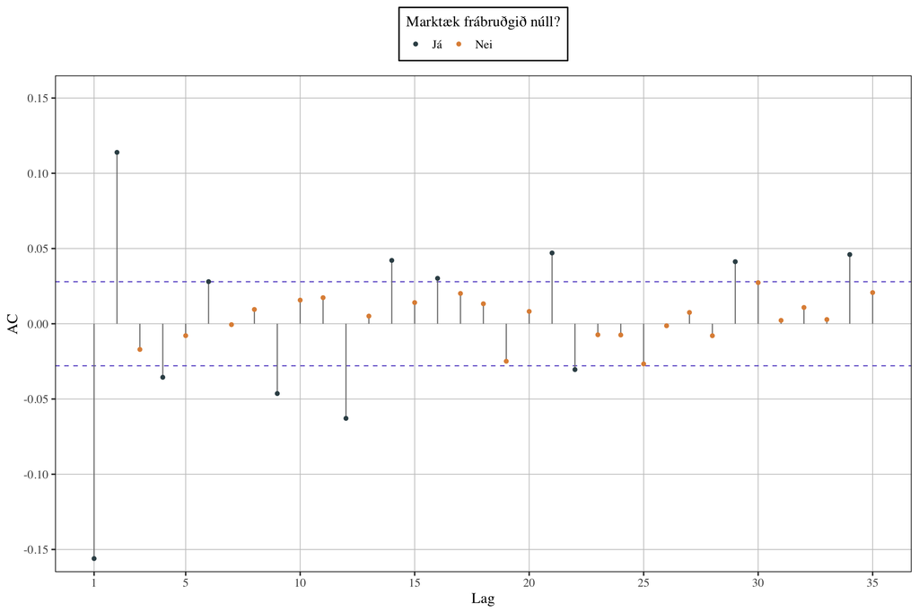

```r
k <- 1:35
col_names <- paste0("lag_", k)
data %>%
      select(Date, Log) %>%
      tq_mutate(select = Log, mutate_fun = lag.xts, k = k,
                col_rename = col_names) %>%
      gather(Lag, value, -Date, -Log) %>%
      mutate(Lag = factor(Lag, levels = col_names, labels = k),
             Lag = as.character(Lag),
             Lag = as.numeric(Lag)) %>%
      group_by(Lag) %>%
      summarize(AC = cor(Log, value, use = "pairwise.complete.obs"),
                Type = ifelse(abs(AC) >= qnorm(0.975) / sqrt(n()),
                              "Já",
                              "Nei")) %>%
      mutate(Lag = str_extract(Lag, "[0-9]+") %>% as.numeric) %>%
      ggplot(aes(Lag, AC, col = Type)) +
      geom_hline(yintercept = qnorm(0.975) / sqrt(nrow(data)), lty = 2, col = "slateblue") +
      geom_hline(yintercept = qnorm(0.025) / sqrt(nrow(data)), lty = 2, col = "slateblue") +
      geom_segment(aes(xend = Lag, yend = 0), col = "gray50") +
      geom_point() +
      scale_x_continuous(breaks = c(1, seq(5, 35, 5))) +
      scale_y_continuous(breaks = pretty_breaks(8)) +
      coord_cartesian(ylim = c(-0.15, 0.15)) +
      scale_color_jama(guide = guide_legend(title = "Marktæk frábruðgið núll?",
                                            title.position = "top",
                                            title.hjust = 0))
```

- Er sjálffylgni lograávöxtunarinnar marktækt frábrugðin núlli? Notið heildarpróf Ljung-Box með R-fallinu ‘Box.test’ til að draga ályktun.

```r
Box.test(data$Log, type = "Ljung")
```

```
##
##  Box-Ljung test
##
## data:  data$Log
## X-squared = 119.85, df = 1, p-value < 2.2e-16
```